# Seventh Week: Generalized Linear Models

Murder or suicide

94101448

2018-04-27 21:42:42

> با توجه به سوالات مرگ و میر در آمریکا به سوالات زیر پاسخ دهید.

```r
library(readxl)
library(ggplot2)
library(dplyr)
library(highcharter)
library(ggcorrplot)

death = read.csv("/Users/macbook/Documents/university/term6/data analysis/data/murder_suicide.csv")
```

۱. از میان متغیرهای داده مرگ و میر یک زیرمجموعه ایی بدون حشو در نظر بگیرید. ماتریس همبستگی متغیرهای مختلف را به دست آورده و سپس رسم نمایید. علاوه بر این نمودار پراکنش متغیرهای انتخاب شده را همزمان نسبت به هم رسم نمایید.

چون خیلی کند بود فقط برای چتد متغیر که فکر میکردم نمودار پراکنش جالبی داشته باشند رسم کردم.

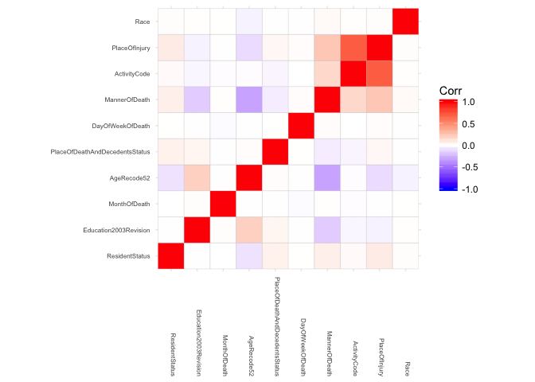

```r
#clean the data
temp1=death[1:54379,]
drops <- c("Id","Education1989Revision","EducationReportingFlag","HispanicOriginRaceRecode",
           'HispanicOrigin','RaceRecode3','RaceRecode5','BridgedRaceFlag',
           'RaceImputationFlag','NumberOfRecordAxisConditions',
           'NumberOfEntityAxisConditions','CauseRecode39','CauseRecode113',
           'CauseRecode358','InfantCauseRecode130',"AgeType","AgeRecode12",
           "AgeRecode27","InfantAgeRecode22","AgeSubstitutionFlag","Age","CurrentDataYear")

data=temp1[ , !(names(temp1) %in% drops)]

data$MaritalStatus=as.factor(data$MaritalStatus)
data$Autopsy=as.factor(data$Autopsy)
data$InjuryAtWork=as.factor(data$InjuryAtWork)
data$Icd10Code=as.factor(data$Icd10Code)
data$Sex=as.factor(data$Sex)
data$MethodOfDisposition=as.factor(data$MethodOfDisposition)
data$MannerOfDeath=data$MannerOfDeath-2

#correlatioan matrix and its visualization:
cormat=cor(data[sapply(data, function(x) is.numeric(x))])
cordata=data.frame(cormat)
ggcorrplot(cordata)+
  theme(axis.text.x = element_text(angle = -90,vjust = 0,size=6),axis.text.y=element_text(size=6))
```

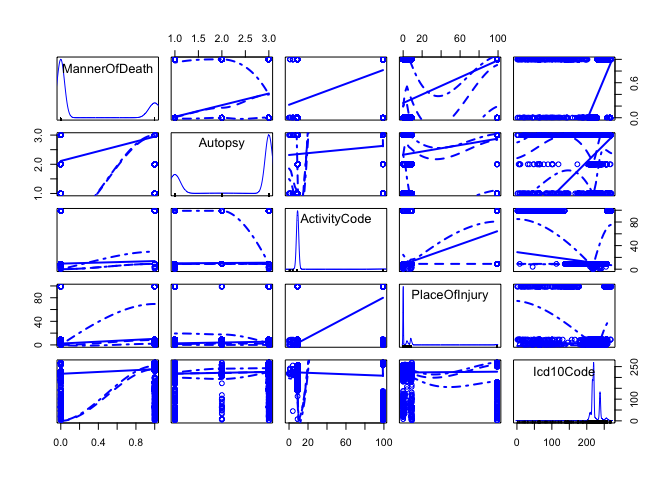

```r
#scatterplot:
library("car")
scatterplotMatrix(data[,c(10,12,13,14,15)])
```

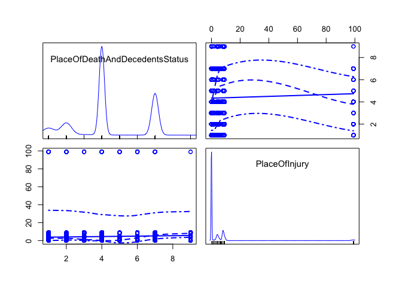

```r
scatterplotMatrix(data[,c(6,14)])#collinearity nadasht.
```

۲. اثر هر یک از متغیرهای جنسیت، نژاد،آموزش، سن و نحوه تدفین را بر مرگ یا خودکشی ارزیابی کنید.

```r
Sex=as.numeric(data$Sex)
MethodOfDisposition=as.numeric(data$MethodOfDisposition)

cor.test(Sex,data$MannerOfDeath)
```

```
##
##  Pearson's product-moment correlation
##
## data:  Sex and data$MannerOfDeath
## t = 4.7833, df = 54377, p-value = 1.729e-06
## alternative hypothesis: true correlation is not equal to 0
## 95 percent confidence interval:
##  0.01210523 0.02890803
## sample estimates:
##        cor
## 0.02050808
```

```r
cor.test(data$Race,data$MannerOfDeath)
```

```
##
##  Pearson's product-moment correlation
##
## data:  data$Race and data$MannerOfDeath
## t = 5.2366, df = 54377, p-value = 1.642e-07
## alternative hypothesis: true correlation is not equal to 0
## 95 percent confidence interval:
##  0.01404857 0.03084997
## sample estimates:
##        cor
## 0.02245086
```

```r
cor.test(data$Education2003Revision,data$MannerOfDeath)
```

```
##
##  Pearson's product-moment correlation
##
## data:  data$Education2003Revision and data$MannerOfDeath
## t = -40.308, df = 54377, p-value < 2.2e-16
## alternative hypothesis: true correlation is not equal to 0
## 95 percent confidence interval:
##  -0.1784806 -0.1621584
## sample estimates:
##        cor
## -0.1703311
```

```r
cor.test(data$AgeRecode52,data$MannerOfDeath)
```

```
##
##  Pearson's product-moment correlation
##
## data:  data$AgeRecode52 and data$MannerOfDeath
## t = -76.222, df = 54377, p-value < 2.2e-16
## alternative hypothesis: true correlation is not equal to 0
## 95 percent confidence interval:
##  -0.3182674 -0.3030801
## sample estimates:
##        cor
## -0.3106936
```

```r
cor.test(MethodOfDisposition,data$MannerOfDeath)
```

```
##
##  Pearson's product-moment correlation
##
## data:  MethodOfDisposition and data$MannerOfDeath
## t = -14.113, df = 54377, p-value < 2.2e-16
## alternative hypothesis: true correlation is not equal to 0
## 95 percent confidence interval:
##  -0.06878086 -0.05203234
## sample estimates:
##         cor
## -0.06041085
```

```r
#all had correlation.
```

۳. با استفاده از مدل رگرسیون لاجستیک یک مدل به داده ها برازش دهید و سپس آن را نقص یابی کنید.

برای تقص یابی به سیگنیفیکنت بودن ضرایب مدل توجه میکنیم و ضرایبی که سیگنیفیکنت هستند را نگه میداریم و بقیه پارامتر ها را حدف میکنیم تا به مدل زیر میرسیم . از روی نمودار مدل میتوانیم داده های پرت را از دیتاست خود حذف کرده و مدل را بهبود بدهیم .

همچنین چند نمودار و تست و گزاره در نقص یابی مدل به کار برده شد که در زیر و در کامت ها توضیح داده شده است .

```r
mylogit = glm(MannerOfDeath ~Education2003Revision+AgeRecode52+MethodOfDisposition+
                PlaceOfInjury+PlaceOfDeathAndDecedentsStatus+MaritalStatus+ResidentStatus,
                data = data,family = "binomial")
summary(mylogit)
```

```
##
## Call:
## glm(formula = MannerOfDeath ~ Education2003Revision + AgeRecode52 +
##     MethodOfDisposition + PlaceOfInjury + PlaceOfDeathAndDecedentsStatus +
##     MaritalStatus + ResidentStatus, family = "binomial", data = data)
##
## Deviance Residuals:
##     Min       1Q   Median       3Q      Max
## -3.1387  -0.7440  -0.4851   0.8343   2.8693
##
## Coefficients:
##                                 Estimate Std. Error z value Pr(>|z|)
## (Intercept)                     3.824964   0.142097  26.918  < 2e-16 ***
## Education2003Revision          -0.211689   0.007797 -27.150  < 2e-16 ***
## AgeRecode52                    -0.111559   0.003830 -29.130  < 2e-16 ***
## MethodOfDispositionC           -1.072789   0.023302 -46.038  < 2e-16 ***
## MethodOfDispositionD           -1.558163   0.285915  -5.450 5.04e-08 ***
## MethodOfDispositionE           -0.439411   0.160972  -2.730 0.006338 **
## MethodOfDispositionO           -0.067050   0.163460  -0.410 0.681666
## MethodOfDispositionR           -0.222165   0.058833  -3.776 0.000159 ***
## MethodOfDispositionU           -1.264403   0.048550 -26.044  < 2e-16 ***
## PlaceOfInjury                   0.042547   0.001314  32.388  < 2e-16 ***
## PlaceOfDeathAndDecedentsStatus -0.064978   0.005285 -12.294  < 2e-16 ***
## MaritalStatusM                 -0.179625   0.035503  -5.059 4.20e-07 ***
## MaritalStatusS                  0.523468   0.034559  15.147  < 2e-16 ***
## MaritalStatusU                  1.300599   0.105703  12.304  < 2e-16 ***
## MaritalStatusW                  0.236931   0.060823   3.895 9.80e-05 ***
## ResidentStatus                  0.146404   0.020904   7.004 2.49e-12 ***
## ---
## Signif. codes:  0 '***' 0.001 '**' 0.01 '*' 0.05 '.' 0.1 ' ' 1
##
## (Dispersion parameter for binomial family taken to be 1)
##
##     Null deviance: 65083  on 54378  degrees of freedom
## Residual deviance: 52652  on 54363  degrees of freedom
## AIC: 52684
##
## Number of Fisher Scoring iterations: 5
```

```r
# 1:  the model has the lowest AIC achieved.
# 2:ttest
diff=mylogit$fitted.values-data$MannerOfDeath
t.test(diff,mu=0)
```

```
##
##  One Sample t-test
##
## data:  diff
## t = -1.1653e-07, df = 54378, p-value = 1
## alternative hypothesis: true mean is not equal to 0
## 95 percent confidence interval:
##  -0.003334524  0.003334524
## sample estimates:
##     mean of x
## -1.982537e-10
```

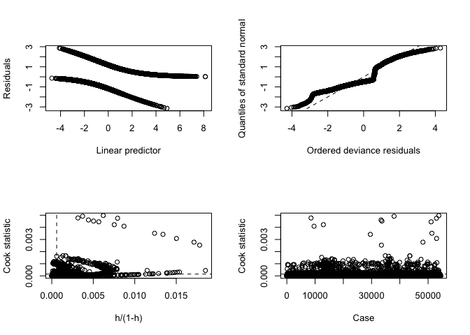

```r
#natavanestim rad konim k fitted value ba actual value fargh darad.
# 3: diagnostic plots:
library(boot)
glm.diag.plots(mylogit, glmdiag = glm.diag(mylogit))
```

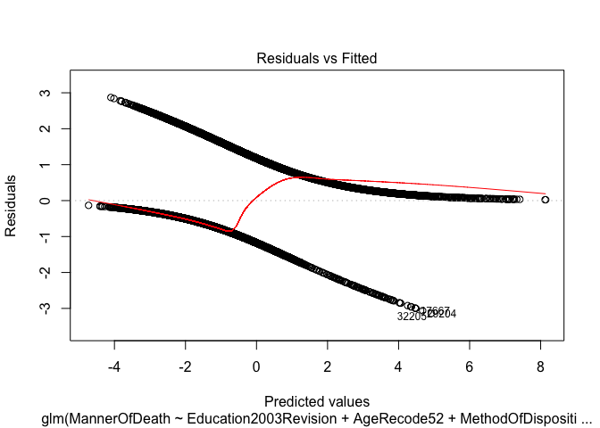

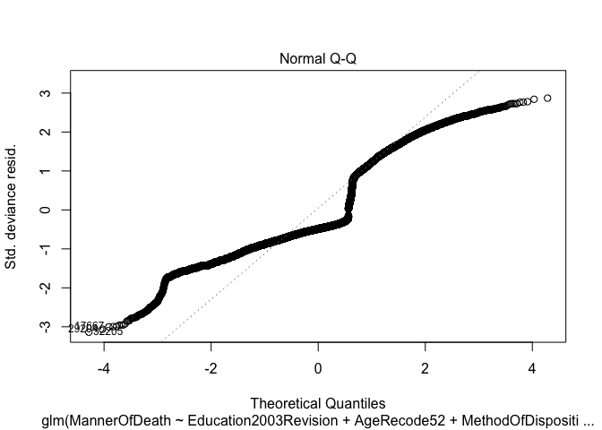

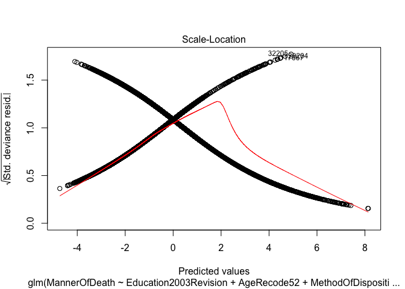

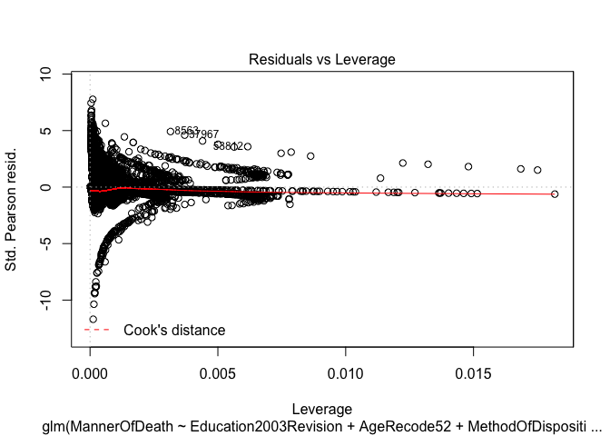

```r
#4:
plot(mylogit)
```

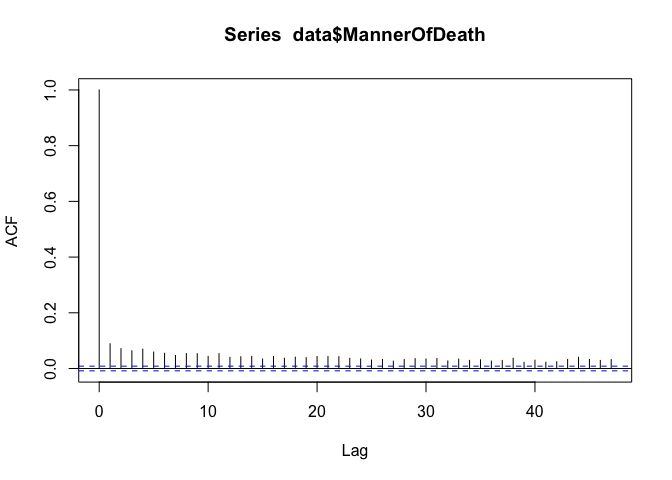

```r
#residuals are not really normally disturbuted
#cook dist is large in the leftmost data points on the scatter plot
#& also we see some outliers

acf(data$MannerOfDeath)
```

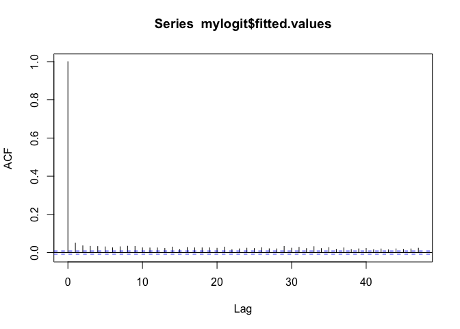

```r
#y points are not independant.
acf(mylogit$fitted.values)
```